# Project Phase 3

Jonathan Zhu

3/17/2022

# Introduction

## Research Question

*To what extent can we use temporal and meteorological data to predict* PM$_{2.5}$ *levels in Beijing, Chengdu, Guangzhou, Shanghai, and Shenyang, and to what extent would our resulting model be able to simulate new meteorological conditions in the future?*

The dataset used in this project contains the PM$_{2.5}$ levels in five Chinese cities: Beijing, Chengdu, Guangzhou, Shanghai, and Shenyang, collected over the years 2010-2015. The data were sourced from “PM2.5 data reliability, consistency, and air quality assessment in five Chinese cities” (Liang et al., 2016) in the Journal of Geophysical Research: Atmospheres via the University of California - Irvine Machine Learning Repository (https://archive.ics.uci.edu/ml/datasets/PM2.5+Data+of+Five+Chinese+Cities#) and were provided to the repository by Song Xi Chen, one of the authors of the journal article.

The research question poses serious implications for public helath; PM$_{2.5}$ levels above 55.5 $\mu g/m^3$ are considered unhealthy, and levels above 250.5 $\mu g/m^3$ are considered hazardous. High PM$_{2.5}$ exposure has been linked to decreased lung function and increased risk of cardiovascular diseases, and they can especially harmful for infants or those with preexisting conditions such as asthma. PM$_{2.5}$ levels have been an increasing concern in China due to the country’s high industrialization and massive cities; all five of the cities from which the data were collected have well over 5 million people, with Shanghai, the most populous, having close to 30 million.

While the world’s global commitment to reducing carbon emissions, as well as some government and international standards for air quality, have decreased PM$_{2.5}$ levels worldwide, some conditions may lead to higher PM$_{2.5}$ levels than normal, requiring protective action such as wearing masks or respirators and using air purifiers. As such, being able to reliably predict PM$_{2.5}$ levels based on temporal or other meteorological conditions will significantly benefit public health as the public would be warned well in advance of the high PM$_{2.5}$ levels occurring and can be better prepared.

## Description of Data

The dataset used contains the following variables:

- PM$_{2.5}$ (Particulate Matter 2.5) levels at various locations in the city in $\mu g/m^3$, which refers to the amount particulate air pollutants less than 2.5 $\mu m$ in width in the air;
- The time which the data in the row was collected, including the current month, day of the month, and season;
- Meteorological data of the city for the specified hour, including:
  - Dew Point in ºC (dewp),
  - Temperature in ºC (temp),
  - Humidity in % (humi).
  - Pressure in hectopascals (hPa) (pres),
  - Overall wind direction (cbwd),
  - Total wind speed in m/s (iws),
  - Precipitation in mm (precipitation),
  - Cumulative precipitation in mm (iprec).

A total of 17 variables exist in each of the datasets except for Beijing, which has 18; this is because Beijing data record PM$_{2.5}$ levels at 4 locations, while the other data record PM$_{2.5}$ levels at 3 locations. Each dataset has 52,584 observations, one for every hour in the years 2010-2015.

While all of the hours in the years 2010-2015 are recorded in the data for every city, other categories have missing variables.

# Exploratory Data Analysis

## Combining Data

Before any exploratory data analysis can be done, we first manipulate the datasets so as to resolve any missing PM$_{2.5}$ values; there are a lot of missing values, but some sites in some cities have more missing values than others. As a result, I split each city’s dataset into subsets for each site within the city and removed the N/A values from these subsets. I also added the city and the site to each subset. I considered imputation for this step but decided it was unnecessary for the purposes of explorartory data analysis.

I then combined all the smaller datasets into larger datasets for each city and one very large dataset with values from all the cities. Even with removing missing PM$_{2.5}$ readings, this large dataset still contains a total of 439,214 observations. This amount is substantial enough to justify removal and not imputation of missing values, which would take more computing time and potentially not add anything new to the model.

## Summaries

### Outcome Variable Statistics

First, we calculate some basic summary statistics of the outcome variable, the PM$_{2.5}$ level, including the mean, standard deviation, and 5-number summary.

Numerical Summary of PM2.5 Levels

| Mean | Variance | Standard Deviation | Min | 25% | Median | 75% | Max |
| --- | --- | --- | --- | --- | --- | --- | --- |
| 72.6189 | 4646.315 | 68.16388 | 1 | 28 | 52 | 92 | 1528 |

Boxplots are then used to identify outliers within the outcome variable.

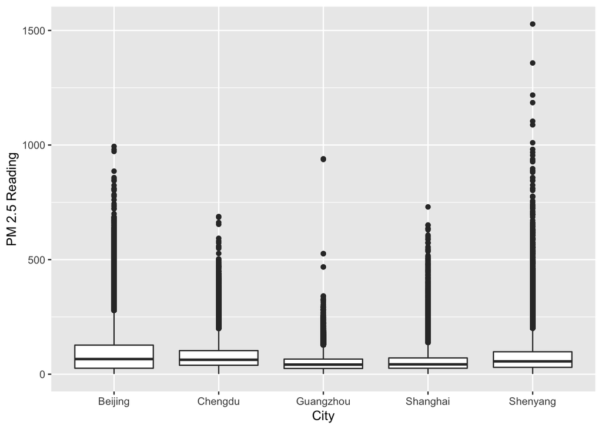

By visual inspection, we easily see that for every city, there are generally a lot of outliers, where an outlier here is defined as being $1.5*$IQR away from the 25th or 75th quartile. These are shown as individual dots on the plots, but the sheer number of them creates what looks like a thick line. Outliers are likely present as PM$_{2.5}$ levels have not been fluctuating around a single level in China; in fact, during the time period of the collection of these data, Shenyang was the most polluted city in the world, explaining why it has the largest PM$_{2.5}$ value in the set.

### Predictor Summary Statistics

First, we look at the correlation between all the numeric predictors and view them both as a visual correlation matrix:

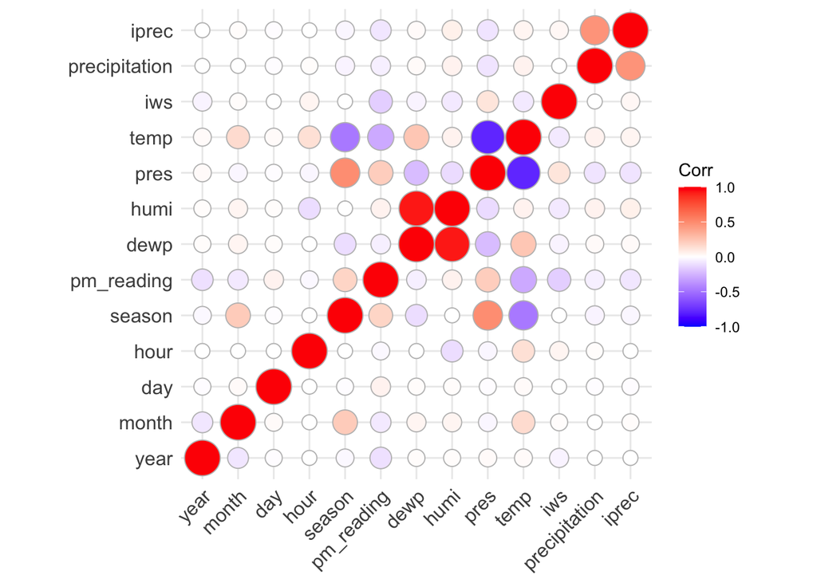

By visually inspecting the correlation matrix, we can see that a lot of the variables are not highly correlated with each other, with two exceptions. Firstly, humidity and dew point have a correlation of 0.93. The dew point is defined as the temperature to which the air must be cooled in order to reach 100% humidity. More moisture in the air would lead to a higher dew point, so it thus makes sense as to why these variables are highly correlated. The other exception is pressure and temperature. The ideal gas law ($PV=nRT$) states that temperature and pressure should be directly proportional keeping other conditions constant, so this correlation is unexpected.

Next, we look at the mean PM$_{2.5}$ value for each month and hour of the day:

Mean PM 2.5 Levels by Month

| Month | Mean PM 2.5 Level |
| --- | --- |
| 1 | 113.82 |
| 2 | 92.50 |
| 3 | 78.47 |
| 4 | 68.01 |
| 5 | 59.48 |
| 6 | 54.29 |
| 7 | 53.04 |
| 8 | 49.11 |
| 9 | 50.83 |
| 10 | 78.30 |
| 11 | 78.41 |
| 12 | 95.11 |

Mean PM 2.5 Levels by Hour of Day

| Month | Mean PM 2.5 Level |
| --- | --- |
| 0 | 77.69 |
| 1 | 77.22 |
| 2 | 76.86 |
| 3 | 75.98 |
| 4 | 74.85 |
| 5 | 73.89 |
| 6 | 73.96 |
| 7 | 74.44 |
| 8 | 75.45 |
| 9 | 75.31 |
| 10 | 73.92 |
| 11 | 71.19 |
| 12 | 69.36 |
| 13 | 66.82 |
| 14 | 64.83 |
| 15 | 63.85 |
| 16 | 63.88 |
| 17 | 65.49 |
| 18 | 68.61 |
| 19 | 72.83 |
| 20 | 75.66 |
| 21 | 76.60 |
| 22 | 77.33 |
| 23 | 77.48 |

The summary statistics for the month and the hour of the day are likely useless, hence why we treated them in this manner. We do the same for season and combined wind direction:

Mean PM 2.5 Levels by Season

| Season | Mean PM 2.5 Level |
| --- | --- |
| 1 | 68.72 |
| 2 | 52.09 |
| 3 | 69.07 |
| 4 | 100.55 |

Mean PM 2.5 Levels For Every Combined Wind Direction

| Wind Direction | Mean PM 2.5 Level |
| --- | --- |
| cv | 100.31 |
| NE | 58.66 |
| NW | 64.10 |
| SE | 79.07 |
| SW | 65.46 |

For the remaining variables, we do not perform the above tabular summary as there are a wide variety of values, including a myriad of decimal options, for each variable. Instead, we treat them similar to the outcome variable by listing key summary statistics.

| Predictor | Mean | Variance | Standard Deviation | Min | 25% | Median | 75% | Max |
| --- | --- | --- | --- | --- | --- | --- | --- | --- |
| dewp | 8.3159025 | 2062.989257 | 45.420141 | -9999 | 0 | 11.00 | 19.0 | 28.0 |
| humi | 65.5426859 | 2446.593778 | 49.463055 | -9999 | 50 | 69.79 | 85.0 | 100.0 |
| iprec | 0.6284832 | 27.234823 | 5.218699 | 0 | 0 | 0.00 | 0.0 | 226.4 |
| iws | 20.9734929 | 2012.844635 | 44.864737 | 0 | 2 | 5.00 | 18.0 | 691.0 |
| precipitation | 0.1221899 | 1.355165 | 1.164116 | 0 | 0 | 0.00 | 0.0 | 90.4 |
| pres | 1013.6137060 | 100.717979 | 10.035835 | 975 | 1006 | 1013.00 | 1021.0 | 1046.0 |
| temp | 15.9536101 | 120.987132 | 10.999415 | -27 | 9 | 18.00 | 24.5 | 42.0 |

## Data Visualization

I plotted visualizations of four predictor variables versus PM$_{2.5}$ readings; those predictor variables are the month, the hour of the day, the temperature, and the wind speed. The month and the hour of the day were previously given as numeric summaries, so plotting their relationship with PM$_{2.5}$ readings gives greater insight into how well a regression model might perform. For temperature, I predict that since higher temperature makes air rise, PM$_{2.5}$ levels will generally be negatively related to temperature; I also predict that since higher wind speeds will blow particles away, higher wind speeds will also have a generally negative relationship with PM$_{2.5}$ levels.

#### Month

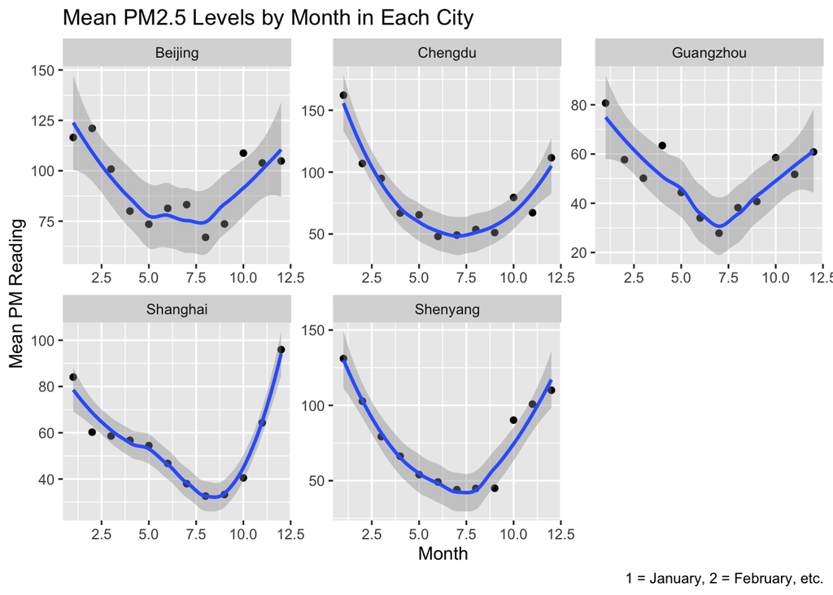

By visual inspection, the mean PM$_{2.5}$ reading has a relationship with the month of the year. The summer months (June, July, and August) generally have the lowest PM$_{2.5}$ levels, while the winter months (December, January, and February) tend to have the highest. This trend is visualized across all five cities. The parabolic shape of these curves indicates a typical linear regression may not work very well for the month as a predictor.

#### Time of Day

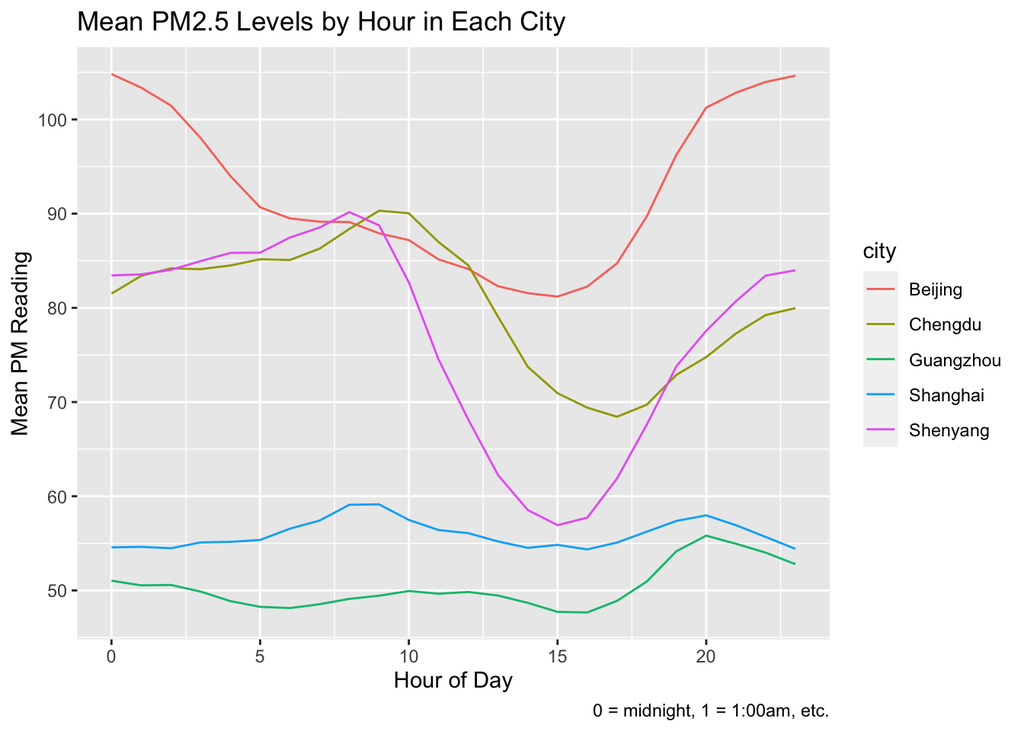

Across the cities, the relationship between the time of the day and PM$_{2.5}$ levels varies; for Beijing, Chengdu, and Shenyang, the relationship is visible. For those three cities, the evening seems to have a generally higher PM$_{2.5}$ reading, with Chengdu and Shenyang reaching a local maximum PM$_{2.5}$ reading at around 8 AM. Similar to the month plot, the oscillating nature of these plots would mean a standard linear regression would not perform well using the hour of the day as a predictor. Guangzhou and Shanghai, on the other hand, have PM$_{2.5}$ levels that do not oscillate nearly as much depending on the time of day.

#### Temperature

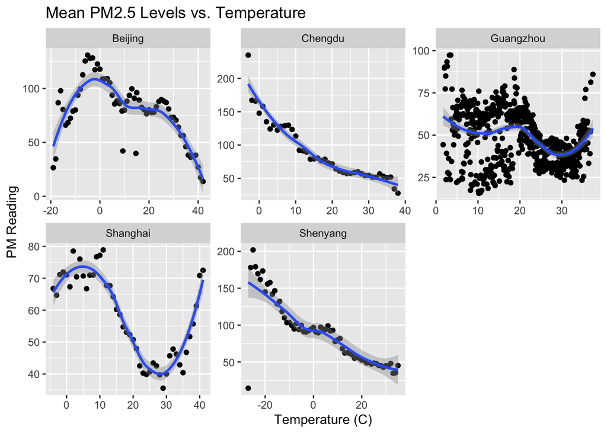

By visually inspecting the plot, the temperature has a clear relationship with the PM$_{2.5}$ reading in all cities except Guangzhou. The relationship changes from city to city, with Chengdu and Shenyang having a linear relationship and Beijing and Shanghai having a more polynomial-like relationship, with Beijing reaching a general maximum at around -5 degrees and Shanghai reaching a general maximum at both 5 and 40 degrees. This would indicate that, like the month and the hour of the day, the predictor would need to be modified somewhat; a standard linear regression would not perform very well otherwise.

#### Wind Speed

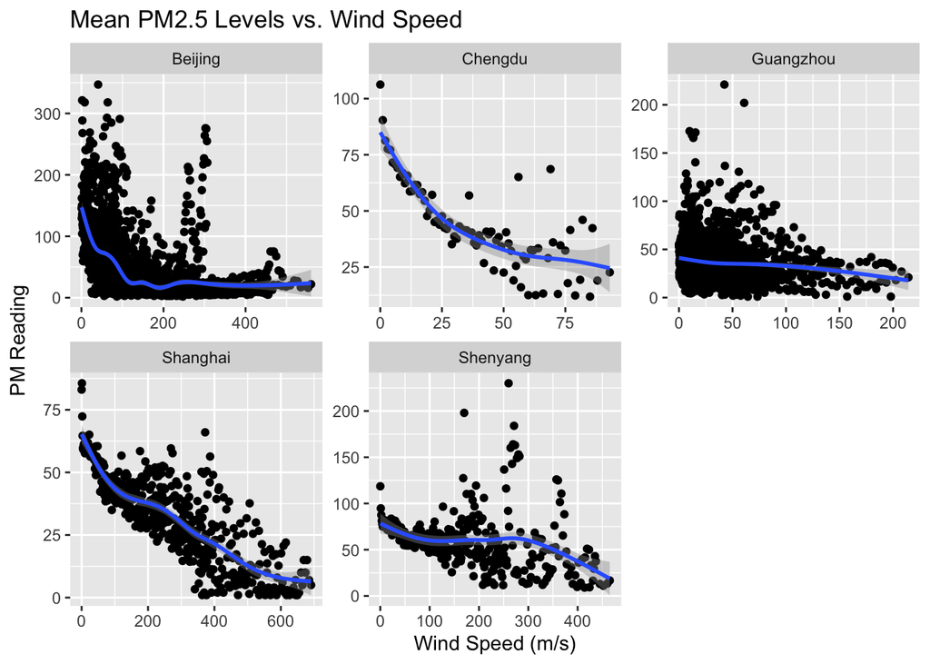

## Conclusions from EDA

Overall, this exploratory data analysis has revealed several key insights:

1. Simply removing the missing PM$_{2.5}$ readings still yields a significant quantity of data;
2. The PM$_{2.5}$ level data contain a large quantity of outliers;
3. Predictors such as the month, the hour of the day, and the temperature would need to be linearized in order to accurately predict under a standard linear regression model, or the model would need to account for nonlinear relationships within the data;
4. The cities vary widely in terms of the relationships between their meteorological conditions and their PM$_{2.5}$ levels; no one standard regression model would accurately predict the PM$_{2.5}$ level in every city at once.

# Methods

Firstly, I defined a preprocessing recipe that specifies a step to remove the non-numeric variables from the dataset, those being number, city, site, and combined wind direction. The recipe then specifies steps to remove N/A values from the predictor variables and remove highly correlated predictors at the 0.7 correlation threshold.

I next took the data for a single city, that being Beijing, and took a random sample of 10,000 data points so as to ensure that a personal computer could run the code; this sample was split into training and testing subsets, and different data folds were created for tuning. In applying a regression to the data, I started with a standard multiple linear regression with no tuned values as a baseline for the most barebones model for predicting PM$_{2.5}$ levels. I then applied the following models to the Beijing data:

- Elastic Net, tuning the amount of penalty and the amount of ridge/LASSO regression in the mixture;
- Single-Layer Neural Net, tuning the number of hidden units, the amount of penalty, and the number of epochs;
- Linear, Polynomial, and Radial Support Vector Machines (SVM), tuning the cost and margin for all, the degree and scale factor for the polynomial, and for the radial, a parameter called rbf_sigma involved in the creation of the support vectors;
- Random Forest, tuning the number of trees, mtry, and the minimum number of points required to go another layer deeper in the tree;
- XG Boosted Random Forest, tuning same parameters as the random forest as well as the maximum tree depth, the learning rate of the model between iterations, the loss reduction required for a further split, the sample size of data exposed to the fitting, and the number of iterations without improvement before stopping.

# Results

For all models exclusively on Beijing data, the results are given in the below table.

RMSE and Rsq for all models on Beijing Data

| Metric | Value | Method |
| --- | --- | --- |
| rmse | 74.481 | Standard Linear Regression |
| rsq | 0.257 | Standard Linear Regression |
| rmse | 74.460 | Elastic Net |
| rsq | 0.257 | Elastic Net |
| rmse | 69.065 | Neural Net |
| rsq | 0.360 | Neural Net |
| rmse | 76.940 | Linear SVM |
| rsq | 0.243 | Linear SVM |
| rmse | 74.226 | Polynomial SVM |
| rsq | 0.305 | Polynomial SVM |
| rmse | 53.363 | Radial SVM |
| rsq | 0.622 | Radial SVM |
| rmse | 63.430 | Random Forest |
| rsq | 0.548 | Random Forest |
| rmse | 48.825 | XG Boosted Forest |
| rsq | 0.681 | XG Boosted Forest |

The standard linear regression produced an RMSE of 74.481 and an R$^2$ value of 0.257, so further models sought to improve those metrics. The elastic net improved RMSE very slightly, which is understandable considering it is just another form of linear regression. On a similar vein, the Linear SVM actually had the worst metrics out of all the models, even the standard linear regression, likely because the support vectors guided a linear model similar to the standard linear regressions.

The best performing models were the Radial SVM, Random Forest, and XG Boosted Forest, with the XG Boosted forest leading all models in R$^2$ and RMSE, likely because these algorithms are even better fit to navigate the curving nature of the relationships in the data, or can split the data into more manageable pieces so that not all the relationships have to be handled at once. The XG Boosted model with a tuning grid size of 302 provided the best RMSE and R$^2$ values among all the tuning grids I tested, so this was then applied to random samples of the other four cities, yielding the following metrics:

RMSE and Rsq for XG Boosted Forest models on data from all five cities

| Metric | Value | City |
| --- | --- | --- |
| rmse | 48.825 | Beijing |
| rsq | 0.681 | Beijing |
| rmse | 30.724 | Chengdu |
| rsq | 0.715 | Chengdu |
| rmse | 24.417 | Guangzhou |
| rsq | 0.541 | Guangzhou |
| rmse | 24.977 | Shanghai |
| rsq | 0.684 | Shanghai |
| rmse | 41.665 | Shenyang |
| rsq | 0.695 | Shenyang |

Beijing was actually the worst-performing city out of the five in RMSE. Chengdu had the best R$^2$ value, which is not surprising considering that exploratory data analysis showed little variation among the Chengdu data. Surprisingly, Guangzhou had the best RMSE; I was expecting that Guangzhou would lead to the worst-performing model considering all the variation seen in exploratory data analysis of Guangzhou’s meteorological data.

# Discussion

Overall, even without the removal of outliers, the algorithms performed fairly well on otherwise noisy and difficult-to-navigate meteorological data. RMSE values, as such, were larger than anticipated; if used for real-world analysis, it would lead to a high variance in the predictions of PM$_{2.5}$ data based on the meteorological conditions. Removal of these outliers would have been preferred, but given the large quantity of them, I was hesitant to do so; this is likely a good starting point for future model development and would be good for cities where PM$_{2.5}$ levels are more consistent.

R$^2$ values, on the other hand, were much higher than expected given the amount of noise in the data. Hence, the majority of the time, predicted PM$_{2.5}$ values were farily close to the actual level, and since overall PM$_{2.5}$ levels in China and worldwide have been decreasing and have been more consistent since these data were collected, I anticipate that a model based on current data would have an even higher R$^2$ and lower RMSE than the models in this project.

Hence, PM$_{2.5}$ levels can be predicted fairly accurately across all five cities with an XG Boosted Forest algorithm, with the exception of certain outlying PM$_{2.5}$ readings. As such, for cities that do not experience incredibly inconsistent amounts or incredibly high amounts of pollution, the model created in this project would be good at informing public health action, such as including advisories with the weather report for the day. This would be especially important if the model predicted a high PM$_{2.5}$ reading for the day as it would necessitate mask-wearing and usage of high-quality filters indoors, advisories for which can be broadcasted on television with the weather report.

One main drawback of the study was the lack of a more general model for the entire country; this might be worth studying for smaller countries, however. While the models each individually performed well for their respective cities, a general model would be hard to create and implement aside from incredibly consistent data, which was not present when making these models. General trends were visible in the exploratory data analysis, such as summer months having low PM$_{2.5}$ levels compared to the winter months, but other trends such as the relation with wind speed and temperature were harder to generalize. In addition, a general model would likely fail for a large country such as China as meteorological conditions vary widely across the country, as do pollution levels.

In addition, while meteorological data can be used to predict PM$_{2.5}$ levels well (as demonstrated by model metrics), the constructed models demonstrate a linkage, not causation. By far the largest contributor to higher PM$_{2.5}$ levels is the presence of polluting factories, which have a causal relationship with PM$_{2.5}$ levels as factories release these particles into the air. As such, a good area for future study would be to investigate the relationship between living conditions, such as median salary, with PM$_{2.5}$ levels. I predict that lower-quality living conditions, especially higher poverty rates, would lead to higher PM$_{2.5}$ levels as factories would be more likely to set up in these areas since they will be more likely to spend less money on labor in these regions. Regulatory laws can also have some effect on the amount of pollution factories release into the air; however, the amount of environmental regulation a city or country imposes is hard to quantify, so the creation of a quantitative index for this kind of regulation would be a good area of future study as well.